> **Tip**: Welcome to the Investigate a Dataset project! You will find tips in quoted sections like this to help organize your approach to your investigation. Before submitting your project, it will be a good idea to go back through your report and remove these sections to make the presentation of your work as tidy as possible. First things first, you might want to double-click this Markdown cell and change the title so that it reflects your dataset and investigation.

# Project: Investigate a Dataset (No-show appointments)

- Introduction
- Data Wrangling
- Exploratory Data Analysis
- Conclusions

## Introduction

> This Investigation aims to analyze the medical appointment show up datatset, investigating what factor affect the frequency of patients showing up to their appointment.

> for example if the patient had scholarship or the duration between setting up the appointment and the actual appointment affect the frequency of showing up?

```python
# Use this cell to set up import statements for all of the packages that you
#   plan to use.

# Remember to include a 'magic word' so that your visualizations are plotted
#   inline with the notebook. See this page for more:
#   http://ipython.readthedocs.io/en/stable/interactive/magics.html
import pandas as pd
import datetime as dt
import numpy as np
import matplotlib
import matplotlib.pyplot as plt
%matplotlib inline
```

## Data Wrangling

> **Tip**: In this section of the report, you will load in the data, check for cleanliness, and then trim and clean your dataset for analysis. Make sure that you document your steps carefully and justify your cleaning decisions.

### General Properties

```python
# Load your data and print out a few lines. Perform operations to inspect data
#   types and look for instances of missing or possibly errant data.
df=pd.read_csv('appointment_data.csv')
df.head()
```

|  | PatientId | AppointmentID | Gender | ScheduledDay | AppointmentDay | Age | Neighbourhood | Scholarship | Hipertension | Diabetes | Alcoholism | Handcap | SMS_received | No-show |
| --- | --- | --- | --- | --- | --- | --- | --- | --- | --- | --- | --- | --- | --- | --- |
| 0 | 2.987250e+13 | 5642903 | F | 2016-04-29T18:38:08Z | 2016-04-29T00:00:00Z | 62 | JARDIM DA PENHA | 0 | 1 | 0 | 0 | 0 | 0 | No |
| 1 | 5.589978e+14 | 5642503 | M | 2016-04-29T16:08:27Z | 2016-04-29T00:00:00Z | 56 | JARDIM DA PENHA | 0 | 0 | 0 | 0 | 0 | 0 | No |
| 2 | 4.262962e+12 | 5642549 | F | 2016-04-29T16:19:04Z | 2016-04-29T00:00:00Z | 62 | MATA DA PRAIA | 0 | 0 | 0 | 0 | 0 | 0 | No |
| 3 | 8.679512e+11 | 5642828 | F | 2016-04-29T17:29:31Z | 2016-04-29T00:00:00Z | 8 | PONTAL DE CAMBURI | 0 | 0 | 0 | 0 | 0 | 0 | No |
| 4 | 8.841186e+12 | 5642494 | F | 2016-04-29T16:07:23Z | 2016-04-29T00:00:00Z | 56 | JARDIM DA PENHA | 0 | 1 | 1 | 0 | 0 | 0 | No |

```python
df.info()
```

```
<class 'pandas.core.frame.DataFrame'>
RangeIndex: 110527 entries, 0 to 110526
Data columns (total 14 columns):
PatientId         110527 non-null float64
AppointmentID     110527 non-null int64
Gender            110527 non-null object
ScheduledDay      110527 non-null object
AppointmentDay    110527 non-null object
Age               110527 non-null int64
Neighbourhood     110527 non-null object
Scholarship       110527 non-null int64
Hipertension      110527 non-null int64
Diabetes          110527 non-null int64
Alcoholism        110527 non-null int64
Handcap           110527 non-null int64
SMS_received      110527 non-null int64
No-show           110527 non-null object
dtypes: float64(1), int64(8), object(5)
memory usage: 11.8+ MB
```

```python
df.describe()
```

|  | PatientId | AppointmentID | Age | Scholarship | Hipertension | Diabetes | Alcoholism | Handcap | SMS_received |
| --- | --- | --- | --- | --- | --- | --- | --- | --- | --- |
| count | 1.105270e+05 | 1.105270e+05 | 110527.000000 | 110527.000000 | 110527.000000 | 110527.000000 | 110527.000000 | 110527.000000 | 110527.000000 |
| mean | 1.474963e+14 | 5.675305e+06 | 37.088874 | 0.098266 | 0.197246 | 0.071865 | 0.030400 | 0.022248 | 0.321026 |
| std | 2.560949e+14 | 7.129575e+04 | 23.110205 | 0.297675 | 0.397921 | 0.258265 | 0.171686 | 0.161543 | 0.466873 |
| min | 3.921784e+04 | 5.030230e+06 | -1.000000 | 0.000000 | 0.000000 | 0.000000 | 0.000000 | 0.000000 | 0.000000 |
| 25% | 4.172614e+12 | 5.640286e+06 | 18.000000 | 0.000000 | 0.000000 | 0.000000 | 0.000000 | 0.000000 | 0.000000 |
| 50% | 3.173184e+13 | 5.680573e+06 | 37.000000 | 0.000000 | 0.000000 | 0.000000 | 0.000000 | 0.000000 | 0.000000 |
| 75% | 9.439172e+13 | 5.725524e+06 | 55.000000 | 0.000000 | 0.000000 | 0.000000 | 0.000000 | 0.000000 | 1.000000 |
| max | 9.999816e+14 | 5.790484e+06 | 115.000000 | 1.000000 | 1.000000 | 1.000000 | 1.000000 | 4.000000 | 1.000000 |

```python
df.duplicated().sum()
```

```
0
```

> **Tip**: You should *not* perform too many operations in each cell. Create cells freely to explore your data. One option that you can take with this project is to do a lot of explorations in an initial notebook. These don't have to be organized, but make sure you use enough comments to understand the purpose of each code cell. Then, after you're done with your analysis, create a duplicate notebook where you will trim the excess and organize your steps so that you have a flowing, cohesive report.

> **Tip**: Make sure that you keep your reader informed on the steps that you are taking in your investigation. Follow every code cell, or every set of related code cells, with a markdown cell to describe to the reader what was found in the preceding cell(s). Try to make it so that the reader can then understand what they will be seeing in the following cell(s).

### Resolving the Data Cleaning Comments

```python
#Changing datatype of column list from int to bool
def change_dtype(df,input_list):
    for column in input_list:
        df[column]=df[column].astype(bool)

input_list=['Scholarship','Hipertension','Diabetes','Alcoholism','Handcap','SMS_received']

change_dtype(df,input_list)
```

```python
#converting PatientID from float to int
df['PatientId']=df['PatientId'].astype(int)
df['PatientId']=df['PatientId'].apply(lambda x: x*-1)
```

```python
#Cleaning ScheduledDay and Appointment Day
df['ScheduledDay'] =  pd.to_datetime(df['ScheduledDay'], format='%Y-%m-%dT%H:%M:%SZ')
df['AppointmentDay'] =  pd.to_datetime(df['AppointmentDay'], format='%Y-%m-%dT%H:%M:%SZ')
df['ScheduledDay'] = pd.to_datetime(df['ScheduledDay']).dt.date
df['AppointmentDay'] = pd.to_datetime(df['AppointmentDay']).dt.date
```

```python
#Investigating ages that are irrational
irrational_ages=df['Age'] < 0
df[irrational_ages]
```

|  | PatientId | AppointmentID | Gender | ScheduledDay | AppointmentDay | Age | Neighbourhood | Scholarship | Hipertension | Diabetes | Alcoholism | Handcap | SMS_received | No-show |
| --- | --- | --- | --- | --- | --- | --- | --- | --- | --- | --- | --- | --- | --- | --- |
| 99832 | 2147483648 | 5775010 | F | 2016-06-06 | 2016-06-06 | -1 | ROMÃO | False | False | False | False | False | False | No |

```python
#Removing Irrational Ages
df=df[df.Age >= 0]
```

```python
# After discussing the structure of the data and any problems that need to be
#   cleaned, perform those cleaning steps in the second part of this section.
df.describe()
```

|  | PatientId | AppointmentID | Age |
| --- | --- | --- | --- |
| count | 1.105260e+05 | 1.105260e+05 | 110526.000000 |
| mean | 2.140311e+09 | 5.675304e+06 | 37.089219 |
| std | 1.508492e+08 | 7.129544e+04 | 23.110026 |
| min | -2.141274e+09 | 5.030230e+06 | 0.000000 |
| 25% | 2.147484e+09 | 5.640285e+06 | 18.000000 |
| 50% | 2.147484e+09 | 5.680572e+06 | 37.000000 |
| 75% | 2.147484e+09 | 5.725523e+06 | 55.000000 |
| max | 2.147484e+09 | 5.790484e+06 | 115.000000 |

## Exploratory Data Analysis

> **Tip**: Now that you've trimmed and cleaned your data, you're ready to move on to exploration. Compute statistics and create visualizations with the goal of addressing the research questions that you posed in the Introduction section. It is recommended that you be systematic with your approach. Look at one variable at a time, and then follow it up by looking at relationships between variables.

### Research Question 1: Does the duration between Scheduled Day and Appointment Day affect showing up?

```python
#create duration column
df['Duration']=df['AppointmentDay']-df['ScheduledDay']
#check if some data has negative number of days
df[df.Duration < dt.timedelta(days=0)]
```

|  | PatientId | AppointmentID | Gender | ScheduledDay | AppointmentDay | Age | Neighbourhood | Scholarship | Hipertension | Diabetes | Alcoholism | Handcap | SMS_received | No-show | Duration |
| --- | --- | --- | --- | --- | --- | --- | --- | --- | --- | --- | --- | --- | --- | --- | --- |
| 27033 | 2147483648 | 5679978 | M | 2016-05-10 | 2016-05-09 | 38 | RESISTÊNCIA | False | False | False | False | True | False | Yes | -1 days |
| 55226 | 2147483648 | 5715660 | F | 2016-05-18 | 2016-05-17 | 19 | SANTO ANTÔNIO | False | False | False | False | True | False | Yes | -1 days |
| 64175 | 2147483648 | 5664962 | F | 2016-05-05 | 2016-05-04 | 22 | CONSOLAÇÃO | False | False | False | False | False | False | Yes | -1 days |
| 71533 | 2147483648 | 5686628 | F | 2016-05-11 | 2016-05-05 | 81 | SANTO ANTÔNIO | False | False | False | False | False | False | Yes | -6 days |
| 72362 | 2147483648 | 5655637 | M | 2016-05-04 | 2016-05-03 | 7 | TABUAZEIRO | False | False | False | False | False | False | Yes | -1 days |

```python
#remove data with negative durations
df=df[df.Duration >= dt.timedelta(days=0)]
```

```python
#create two data frames to Duration distibution of the show and no show
df_show=df[df['No-show']=='No']
df_noshow=df[df['No-show']=='Yes']
```

```python
#convert Duratin to integers
df['Duration']=pd.to_numeric(df['Duration'])*1.15741e-14
```

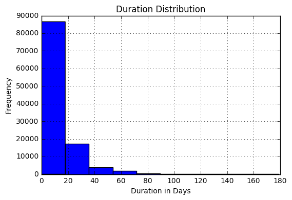

```python
df['Duration'].hist()
plt.title("Duration Distribution")
plt.xlabel("Duration in Days")
plt.ylabel("Frequency")
```

Most Durations are in the magnitude of one month

```python
show_freq=df_show.groupby('Duration').count()['No-show']
noshow_freq=df_noshow.groupby('Duration').count()['No-show']
```

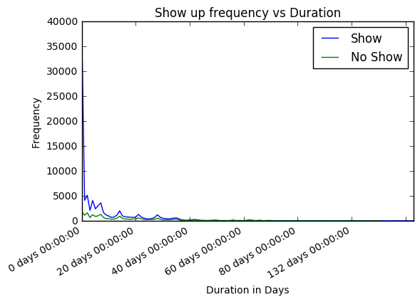

```python
show_freq.plot(label='Show')
noshow_freq.plot(label='No Show')
plt.legend()
plt.title("Show up frequency vs Duration")
plt.xlabel("Duration in Days")
plt.ylabel("Frequency")
```

### Research Question 2 Does being in the Scholarship affect the show up frequency ?

```python
df_scholarship=df[df['Scholarship']==True]
df_noscholraship=df[df['Scholarship']==False]
```

[output not shown]

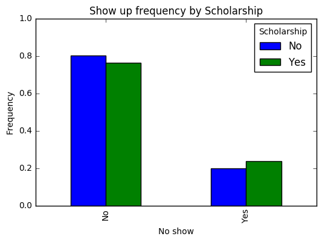

```python
#Calculate frequencies
table=pd.crosstab(df['No-show'],df['Scholarship'],normalize='columns')
table.rename(columns={0:'No',1:"Yes"},inplace=True)

#plot
ax=table.plot.bar()
ax.set(title="Show up frequency by Scholarship",xlabel="No show",ylabel="Frequency", ylim=[0,1])
```

The analysis show that people without scholarship are more likely to show to their appointment although the effect is slight which makes sense because people with no scholarship would be paying more money for the doctor's appointment

```python
# Continue to explore the data to address your additional research
#   questions. Add more headers as needed if you have more questions to
#   investigate.
```

## Conclusions

> people without scholarship are more likely to show to their appointment although the effect is slight

> analysis limitation : Not all factors were analyzed to determine the factors that affect the frequency of showing up, also a more important factor to analyze is the distance between the patient's home and the doctor which is not present in the data

```python
from subprocess import call
call(['python', '-m', 'nbconvert', 'Investigate_a_Dataset.ipynb'])
```

```
0
```